# Data Definition

```python
import sys, os
sys.path.append(os.path.abspath(".."))

from src.utils import *

import pandas as pd
import numpy as np


import matplotlib.pyplot as plt
import seaborn as sns
sns.set_theme()
```

This dataset representing a unique vehicle listing, and includes twelve distinct features providing valuable insights. - Brand: Identify the brand or company name - Model: Specific model of each vehicle - model_year: Manufacturing year of the vehicles, crucial for assessing depreciation and technology advancements - mileage: Mileage of each vehicle, a key indicator of wear and tear and potential maintenance requirements - fuel_type: Type of fuel the vehicle runs on (gasoline, diesel, electric, hybrid, etc.) - engine: Engine specifications - transmission: Transmission type (automatic, manual, or other variants) - ext_col: Exterior color of the car - int_col: Interior color of the car - accident: Vehicle prior history of accidents or damage - clean_title: Indicates whether the vehicle has a clean title (legal status) - price: Price of the vehicle (target variable)

```python
print("Train Dataset")
df_train = load_data("../data/raw/train.csv")

print('\nTest Dataset')
df_test = load_data("../data/raw/test.csv")

print('\nCompetition Submission Format')
df_sample_submission = load_data("../data/raw/sample_submission.csv")
```

```
Train Dataset
Data Shape:  (188533, 12)

Test Dataset
Data Shape:  (125690, 11)

Competition Submission Format
Data Shape:  (125690, 1)
```

```python
df_train.head()
```

| id | brand | model | model_year | milage | fuel_type | engine | transmission | ext_col | int_col | accident | clean_title | price |
| --- | --- | --- | --- | --- | --- | --- | --- | --- | --- | --- | --- | --- |
| 0 | MINI | Cooper S Base | 2007 | 213000 | Gasoline | 172.0HP 1.6L 4 Cylinder Engine Gasoline Fuel | A/T | Yellow | Gray | None reported | Yes | 4200 |
| 1 | Lincoln | LS V8 | 2002 | 143250 | Gasoline | 252.0HP 3.9L 8 Cylinder Engine Gasoline Fuel | A/T | Silver | Beige | At least 1 accident or damage reported | Yes | 4999 |
| 2 | Chevrolet | Silverado 2500 LT | 2002 | 136731 | E85 Flex Fuel | 320.0HP 5.3L 8 Cylinder Engine Flex Fuel Capab... | A/T | Blue | Gray | None reported | Yes | 13900 |
| 3 | Genesis | G90 5.0 Ultimate | 2017 | 19500 | Gasoline | 420.0HP 5.0L 8 Cylinder Engine Gasoline Fuel | Transmission w/Dual Shift Mode | Black | Black | None reported | Yes | 45000 |
| 4 | Mercedes-Benz | Metris Base | 2021 | 7388 | Gasoline | 208.0HP 2.0L 4 Cylinder Engine Gasoline Fuel | 7-Speed A/T | Black | Beige | None reported | Yes | 97500 |

```python
df_test.head()
```

| id | brand | model | model_year | milage | fuel_type | engine | transmission | ext_col | int_col | accident | clean_title |
| --- | --- | --- | --- | --- | --- | --- | --- | --- | --- | --- | --- |
| 188533 | Land | Rover LR2 Base | 2015 | 98000 | Gasoline | 240.0HP 2.0L 4 Cylinder Engine Gasoline Fuel | 6-Speed A/T | White | Beige | None reported | Yes |
| 188534 | Land | Rover Defender SE | 2020 | 9142 | Hybrid | 395.0HP 3.0L Straight 6 Cylinder Engine Gasoli... | 8-Speed A/T | Silver | Black | None reported | Yes |
| 188535 | Ford | Expedition Limited | 2022 | 28121 | Gasoline | 3.5L V6 24V PDI DOHC Twin Turbo | 10-Speed Automatic | White | Ebony | None reported | NaN |
| 188536 | Audi | A6 2.0T Sport | 2016 | 61258 | Gasoline | 2.0 Liter TFSI | Automatic | Silician Yellow | Black | None reported | NaN |
| 188537 | Audi | A6 2.0T Premium Plus | 2018 | 59000 | Gasoline | 252.0HP 2.0L 4 Cylinder Engine Gasoline Fuel | A/T | Gray | Black | None reported | Yes |

```python
df_sample_submission.head()
```

| id | price |
| --- | --- |
| 188533 | 43878.016 |
| 188534 | 43878.016 |
| 188535 | 43878.016 |
| 188536 | 43878.016 |
| 188537 | 43878.016 |

- The train dataset has 188.533 rows and 13 columns (including `id`).
- The test set has 125,690 rows and 12 columns, excluding the price column.
- Submit the prediction of test data to kaggle by using CSV format with `id` as the index and `price` as the column.

### Descriptive Analysis

```python
df_train.info()
```

```
<class 'pandas.core.frame.DataFrame'>
Index: 188533 entries, 0 to 188532
Data columns (total 12 columns):
 #   Column        Non-Null Count   Dtype
---  ------        --------------   -----
 0   brand         188533 non-null  object
 1   model         188533 non-null  object
 2   model_year    188533 non-null  int64
 3   milage        188533 non-null  int64
 4   fuel_type     183450 non-null  object
 5   engine        188533 non-null  object
 6   transmission  188533 non-null  object
 7   ext_col       188533 non-null  object
 8   int_col       188533 non-null  object
 9   accident      186081 non-null  object
 10  clean_title   167114 non-null  object
 11  price         188533 non-null  int64
dtypes: int64(3), object(9)
memory usage: 18.7+ MB
```

- The dataset has three numeric variables, namely `price`, `model_year`, and `mileage`.
- The other variables are categorical.

```python
df_train.describe()
```

|  | model_year | milage | price |
| --- | --- | --- | --- |
| count | 188533.000000 | 188533.000000 | 1.885330e+05 |
| mean | 2015.829998 | 65705.295174 | 4.387802e+04 |
| std | 5.660967 | 49798.158076 | 7.881952e+04 |
| min | 1974.000000 | 100.000000 | 2.000000e+03 |
| 25% | 2013.000000 | 24115.000000 | 1.700000e+04 |
| 50% | 2017.000000 | 57785.000000 | 3.082500e+04 |
| 75% | 2020.000000 | 95400.000000 | 4.990000e+04 |
| max | 2024.000000 | 405000.000000 | 2.954083e+06 |

- The variables `price` and `mileage` have maximum values that are very far from their third quartiles. This indicate outliers.

```python
df_train.describe(exclude=np.number)
```

|  | brand | model | fuel_type | engine | transmission | ext_col | int_col | accident | clean_title |
| --- | --- | --- | --- | --- | --- | --- | --- | --- | --- |
| count | 188533 | 188533 | 183450 | 188533 | 188533 | 188533 | 188533 | 186081 | 167114 |
| unique | 57 | 1897 | 7 | 1117 | 52 | 319 | 156 | 2 | 1 |
| top | Ford | F-150 XLT | Gasoline | 355.0HP 5.3L 8 Cylinder Engine Gasoline Fuel | A/T | Black | Black | None reported | Yes |
| freq | 23088 | 2945 | 165940 | 3462 | 49904 | 48658 | 107674 | 144514 | 167114 |

There are 57 type of `brand`, 1897 type of `model`, 7 type of `fuel`, 52 type of `transmission`, 319 type of `ext_col`, 156 type of `int_col`, 2 categories of `accident`, and 1 category of `clean_title`

### Checking Duplicated Data

```python
df_train[df_train.duplicated(keep=False)]
```

|  | brand | model | model_year | milage | fuel_type | engine | transmission | ext_col | int_col | accident | clean_title | price |
| --- | --- | --- | --- | --- | --- | --- | --- | --- | --- | --- | --- | --- |
| id |  |  |  |  |  |  |  |  |  |  |  |  |

There are NO DUPLICATED DATA.

### Checking Missing Value

```python
df_train.isna().sum()
```

```
brand               0
model               0
model_year          0
milage              0
fuel_type        5083
engine              0
transmission        0
ext_col             0
int_col             0
accident         2452
clean_title     21419
price               0
dtype: int64
```

The variables `accident`, `clean_title`, and `fuel_type` have missing values that must be handled.

### Univariate Analysis

In this part we will analyze each column separately. We’ll start off with the numeric columns and then followed with the categoric ones.

#### `model_year`

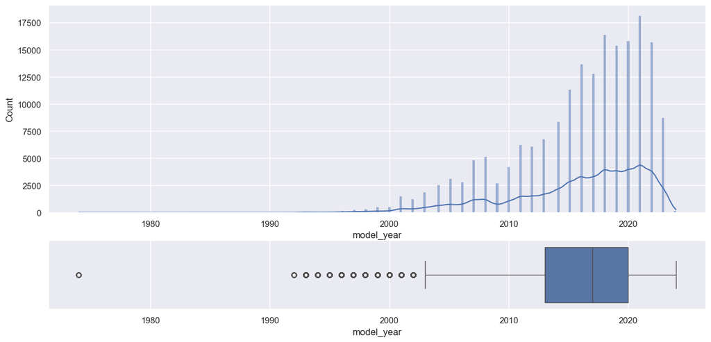

```python
fig, axes = plt.subplots(2, 1, figsize=(15, 7), gridspec_kw={'height_ratios': [3, 1]})
sns.histplot(data=df_train, x='model_year', kde=True, ax=axes[0])
sns.boxplot(x=df_train['model_year'], ax=axes[1])
plt.show()
```

- Most of the cars sold are models from 2000 onwards.
- The variable `model_year` has several outliers that need to be investigated further.

#### `milage`

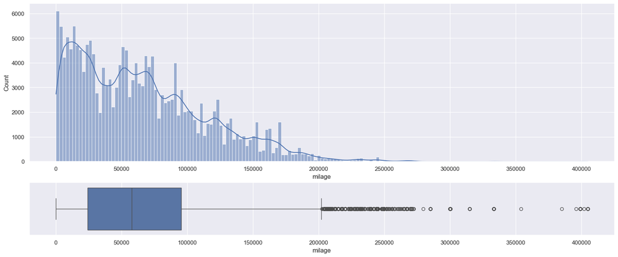

```python
fig, axes = plt.subplots(2, 1, figsize=(20, 8), gridspec_kw={'height_ratios': [3, 1]})
sns.histplot(data=df_train, x='milage', kde=True, ax=axes[0])
sns.boxplot(x=df_train['milage'], ax=axes[1])
plt.show()
```

- The variable `mileage` has many outliers, which makes its distribution highly skewed.

#### `price`

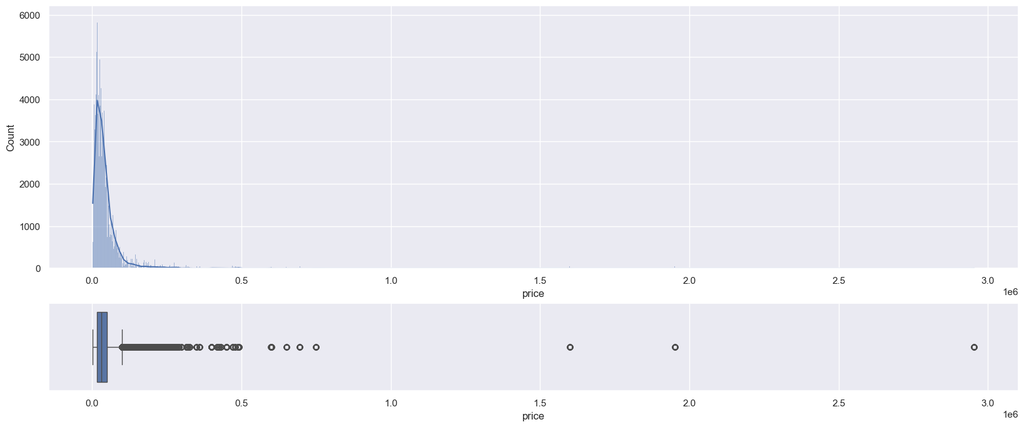

```python
fig, axes = plt.subplots(2, 1, figsize=(20, 8), gridspec_kw={'height_ratios': [3, 1]})
sns.histplot(data=df_train, x='price', kde=True, ax=axes[0])
sns.boxplot(x=df_train['price'], ax=axes[1])
plt.show()
```

This variable is extremely skewed. There are outlier values that are too far from the upper whisker. This needs to be handeld.

#### `brand`

```python
df_train['brand'].nunique()
```

```
57
```

```python
df_train['brand'].value_counts()
```

```
brand
Ford             23088
Mercedes-Benz    19172
BMW              17028
Chevrolet        16335
Audi             10887
Porsche          10612
Land              9525
Toyota            8850
Lexus             8643
Jeep              6474
Cadillac          4674
RAM               4249
Nissan            3930
Tesla             3738
INFINITI          3276
GMC               3215
Dodge             3133
Mazda             2719
Kia               2497
Lincoln           2423
Subaru            2381
Acura             2282
Honda             2101
Hyundai           2045
Volkswagen        1765
Jaguar            1319
Bentley           1155
MINI              1064
Genesis            969
Buick              940
Maserati           939
Lamborghini        809
Chrysler           727
Volvo              723
Alfa               682
Rivian             590
Rolls-Royce        561
Mitsubishi         551
Pontiac            538
Hummer             520
Ferrari            359
McLaren            243
Aston              238
Saturn             148
Scion              120
Lucid               69
Mercury             57
Lotus               52
FIAT                44
Saab                22
Karma               17
Suzuki               8
Plymouth             7
Polestar             7
Bugatti              7
smart                3
Maybach              3
Name: count, dtype: int64
```

```python
df_train['brand'].value_counts(normalize=True)
```

```
brand
Ford             0.122461
Mercedes-Benz    0.101690
BMW              0.090318
Chevrolet        0.086643
Audi             0.057746
Porsche          0.056287
Land             0.050522
Toyota           0.046941
Lexus            0.045843
Jeep             0.034339
Cadillac         0.024791
RAM              0.022537
Nissan           0.020845
Tesla            0.019827
INFINITI         0.017376
GMC              0.017053
Dodge            0.016618
Mazda            0.014422
Kia              0.013244
Lincoln          0.012852
Subaru           0.012629
Acura            0.012104
Honda            0.011144
Hyundai          0.010847
Volkswagen       0.009362
Jaguar           0.006996
Bentley          0.006126
MINI             0.005644
Genesis          0.005140
Buick            0.004986
Maserati         0.004981
Lamborghini      0.004291
Chrysler         0.003856
Volvo            0.003835
Alfa             0.003617
Rivian           0.003129
Rolls-Royce      0.002976
Mitsubishi       0.002923
Pontiac          0.002854
Hummer           0.002758
Ferrari          0.001904
McLaren          0.001289
Aston            0.001262
Saturn           0.000785
Scion            0.000636
Lucid            0.000366
Mercury          0.000302
Lotus            0.000276
FIAT             0.000233
Saab             0.000117
Karma            0.000090
Suzuki           0.000042
Plymouth         0.000037
Polestar         0.000037
Bugatti          0.000037
smart            0.000016
Maybach          0.000016
Name: proportion, dtype: float64
```

```python
np.sort(df_train['brand'].unique())
```

```
array(['Acura', 'Alfa', 'Aston', 'Audi', 'BMW', 'Bentley', 'Bugatti',
       'Buick', 'Cadillac', 'Chevrolet', 'Chrysler', 'Dodge', 'FIAT',
       'Ferrari', 'Ford', 'GMC', 'Genesis', 'Honda', 'Hummer', 'Hyundai',
       'INFINITI', 'Jaguar', 'Jeep', 'Karma', 'Kia', 'Lamborghini',
       'Land', 'Lexus', 'Lincoln', 'Lotus', 'Lucid', 'MINI', 'Maserati',
       'Maybach', 'Mazda', 'McLaren', 'Mercedes-Benz', 'Mercury',
       'Mitsubishi', 'Nissan', 'Plymouth', 'Polestar', 'Pontiac',
       'Porsche', 'RAM', 'Rivian', 'Rolls-Royce', 'Saab', 'Saturn',
       'Scion', 'Subaru', 'Suzuki', 'Tesla', 'Toyota', 'Volkswagen',
       'Volvo', 'smart'], dtype=object)
```

- There are no naming inconsistencies in the `brand` variable.
- The `brand` variable has 57 categories, with Ford as the brand with the most data.
- The most common category accounts for only 12% of the total data.

#### `model`

```python
df_train['model'].nunique()
```

```
1897
```

```python
df_train['model'].value_counts()
```

```
model
F-150 XLT                        2945
M3 Base                          2229
Camaro 2SS                       1709
M4 Base                          1622
Mustang GT Premium               1526
                                 ...
ForTwo Pure                         2
XLR Base                            1
X5 3.0i                             1
X5 xDrive40e                        1
Integra w/A-Spec Tech Package       1
Name: count, Length: 1897, dtype: int64
```

```python
df_train['model'].value_counts(normalize=True)
```

```
model
F-150 XLT                        0.015621
M3 Base                          0.011823
Camaro 2SS                       0.009065
M4 Base                          0.008603
Mustang GT Premium               0.008094
                                   ...
ForTwo Pure                      0.000011
XLR Base                         0.000005
X5 3.0i                          0.000005
X5 xDrive40e                     0.000005
Integra w/A-Spec Tech Package    0.000005
Name: proportion, Length: 1897, dtype: float64
```

```python
df_train['model'].unique()
```

```
array(['Cooper S Base', 'LS V8', 'Silverado 2500 LT', ..., 'e-Golf SE',
       'Integra w/A-Spec Tech Package', 'IONIQ Plug-In Hybrid SEL'],
      shape=(1897,), dtype=object)
```

```python
df_train[(df_train['model']=='Unknown')|(df_train['model']=='other')]['model']
```

```
Series([], Name: model, dtype: object)
```

- There are 1897 unique `model`, with F-150 XLT as the most common.
- The most common category accounts for only 1.5% of the total data.

#### `fuel_type`

```python
df_train['fuel_type'].unique()
```

```
array(['Gasoline', 'E85 Flex Fuel', nan, 'Hybrid', 'Diesel',
       'Plug-In Hybrid', '–', 'not supported'], dtype=object)
```

```python
df_train['fuel_type'].value_counts()
```

```
fuel_type
Gasoline          165940
Hybrid              6832
E85 Flex Fuel       5406
Diesel              3955
–                    781
Plug-In Hybrid       521
not supported         15
Name: count, dtype: int64
```

```python
df_train[df_train['fuel_type'] =='not supported']
```

| id | brand | model | model_year | milage | fuel_type | engine | transmission | ext_col | int_col | accident | clean_title | price |
| --- | --- | --- | --- | --- | --- | --- | --- | --- | --- | --- | --- | --- |
| 4823 | Chevrolet | Suburban LT | 2011 | 109646 | not supported | 320.0HP 5.3L 8 Cylinder Engine Flex Fuel Capab... | 6-Speed A/T | Black | Beige | None reported | Yes | 18998 |
| 18000 | Porsche | Camaro 2SS | 2015 | 67000 | not supported | 240.0HP 2.0L 4 Cylinder Engine Gasoline Fuel | Transmission w/Dual Shift Mode | Black | Black | None reported | Yes | 11500 |
| 19182 | Nissan | Mirai Limited | 2000 | 131000 | not supported | 182.0HP Electric Motor Hydrogen Fuel | A/T | Silver | Black | None reported | Yes | 5000 |
| 27199 | Subaru | Outback 2.5i Limited | 2017 | 116000 | not supported | 175.0HP 2.5L 4 Cylinder Engine Gasoline Fuel | CVT Transmission | Gray | Black | At least 1 accident or damage reported | Yes | 27499 |
| 33030 | Nissan | Mirai Limited | 2009 | 137333 | not supported | 182.0HP Electric Motor Hydrogen Fuel | A/T | White | Gray | At least 1 accident or damage reported | Yes | 12999 |
| 60717 | Chevrolet | Silverado 1500 RST | 2020 | 19200 | not supported | 355.0HP 5.3L 8 Cylinder Engine Gasoline Fuel | 10-Speed A/T | White | Black | At least 1 accident or damage reported | Yes | 58000 |
| 74096 | Toyota | Mirai Limited | 2021 | 79876 | not supported | 182.0HP Electric Motor Hydrogen Fuel | A/T | Red | Black | None reported | Yes | 15000 |
| 86897 | Lexus | IS 350 F Sport | 2022 | 9500 | not supported | 311.0HP 3.5L V6 Cylinder Engine Gasoline Fuel | A/T | Gray | Black | None reported | Yes | 60000 |
| 94425 | Porsche | Cayenne Turbo GT | 2018 | 52000 | not supported | 550.0HP 4.8L 8 Cylinder Engine Gasoline Fuel | Transmission w/Dual Shift Mode | Gray | Gray | At least 1 accident or damage reported | Yes | 35000 |
| 127066 | Toyota | Mirai Limited | 2016 | 58664 | not supported | 151.0HP Electric Motor Hydrogen Fuel | CVT Transmission | Black | Black | At least 1 accident or damage reported | Yes | 22500 |
| 128917 | Mazda | MX-5 Miata Base | 1999 | 120000 | not supported | 140.0HP 1.8L 4 Cylinder Engine Gasoline Fuel | 5-Speed M/T | Black | Beige | At least 1 accident or damage reported | Yes | 4000 |
| 135865 | Lexus | Mirai Limited | 2014 | 123331 | not supported | 182.0HP Electric Motor Hydrogen Fuel | A/T | Red | Gray | At least 1 accident or damage reported | Yes | 11495 |
| 140206 | Lexus | RX 330 Base | 2006 | 110000 | not supported | 230.0HP 3.3L V6 Cylinder Engine Gasoline Fuel | 5-Speed A/T | White | Beige | At least 1 accident or damage reported | Yes | 9500 |
| 171120 | Hummer | H2 Base | 2013 | 152068 | not supported | 316.0HP 6.0L 8 Cylinder Engine Gasoline Fuel | A/T | Black | Black | At least 1 accident or damage reported | Yes | 14000 |
| 171659 | Toyota | Mirai Limited | 2021 | 44000 | not supported | 182.0HP Electric Motor Hydrogen Fuel | A/T | Gray | Black | None reported | Yes | 4900 |

- The variable `fuel_type` has missing values stored as `-`, `not supported`, and `nan`
- There are alot of mismatch between fuel type stated on the `engine` spec and fuel type on the `fuel_type`
- Category `Hydrogen fuel` needs to be added.

#### `engine`

```python
pd.DataFrame(df_train['engine'].unique())
```

|  | 0 |
| --- | --- |
| 0 | 172.0HP 1.6L 4 Cylinder Engine Gasoline Fuel |
| 1 | 252.0HP 3.9L 8 Cylinder Engine Gasoline Fuel |
| 2 | 320.0HP 5.3L 8 Cylinder Engine Flex Fuel Capab... |
| 3 | 420.0HP 5.0L 8 Cylinder Engine Gasoline Fuel |
| 4 | 208.0HP 2.0L 4 Cylinder Engine Gasoline Fuel |
| ... | ... |
| 1112 | 151.0HP 1.5L 4 Cylinder Engine Gas/Electric Hy... |
| 1113 | 184.0HP 2.4L 4 Cylinder Engine Flex Fuel Capab... |
| 1114 | 78.0HP 1.2L 3 Cylinder Engine Gasoline Fuel |
| 1115 | 139.0HP 1.6L 4 Cylinder Engine Plug-In Electri... |
| 1116 | 313.0HP 2.0L 4 Cylinder Engine Plug-In Electri... |

1117 rows × 1 columns

It seems that most of the car uses cylinder engine. Let’s see the proportion!

```python
mask = df_train['engine'].str.contains('cylinder', case=False, na=False) # contain 'cylinder'
```

```python
print("Cylinder :", len(df_train.loc[mask, 'engine'])/ len(df_train))
print("Non-cylinder :",len(df_train.loc[~mask, 'engine'])/ len(df_train))
```

```
Cylinder : 0.7992128698954559
Non-cylinder : 0.20078713010454402
```

- 79.9% engine type in the data contain cylinder.
- Now let’s break down the engine type based on the number of words.

```python
df_copy = df_train.copy()
df_copy['engine_word_count'] = df_copy['engine'].astype(str).str.split().str.len()
df_copy['engine_word_count'].unique()
```

```
array([7, 8, 5, 9, 6, 4, 1, 2, 3])
```

```python
df_copy['engine_word_count'].value_counts(normalize=True)
```

```
engine_word_count
7    0.706890
8    0.118632
5    0.062833
6    0.052882
3    0.018877
2    0.015774
9    0.009346
1    0.008900
4    0.005866
Name: proportion, dtype: float64
```

```python
df_copy[df_copy['engine_word_count']==1]['engine'].unique()
```

```
array(['Electric', '–', 'V6', '4.0L', 'I4', '2.5L', 'V8', '3.0L'],
      dtype=object)
```

```python
df_copy[df_copy['engine_word_count']==2]['engine'].unique()
```

```
array(['2.0 Liter', '3.5 Liter', '5.6 Liter', '5.0 Liter', '3.6 Liter',
       '6.4 Liter', '3.0 Liter', '5.4 Liter', '2.5 Liter', '4.6 Liter',
       '2.4 Liter', '4.0 Liter', '4.4 Liter', '6.2 Liter', '5.7 Liter',
       '120 AH', 'Battery Electric', '5.3 Liter', '5.5 Liter',
       '1.8 Liter'], dtype=object)
```

```python
df_copy[df_copy['engine_word_count']==3]['engine'].unique()
```

```
array(['2.0 Liter Turbo', '3.0 Liter Turbo', '2.0 Liter TFSI',
       '3.6 Liter DOHC', '4.0 Liter TFSI', '3.5 Liter DOHC',
       '3.0 Liter TFSI', '3.5 Liter SOHC', 'Standard Range Battery',
       '2.5L I4 16V', '3.0 Liter GTDI', '12 Cylinder Engine',
       '2.0 Liter Supercharged', '2.0 Liter TSI', '5.0L 8 Cylinder',
       '4.0 Liter Turbo', '2.9 Liter Turbo', '1.5 Liter Turbo',
       '3.5 Liter GTDI'], dtype=object)
```

```python
df_copy[df_copy['engine_word_count']==4]['engine'].unique()
```

```
array(['Dual Motor - Standard', '2.0 Liter DOHC Turbo',
       '3.6 Liter SIDI DOHC', '4.0 Liter Twin Turbo',
       '3.0 Liter Twin Turbo', '3.6L V6 GDI DOHC', '4.7 Liter Twin Turbo',
       '4.4 Liter Twin Turbo', '5.4 Liter SC DOHC',
       '2.7 Liter DOHC Turbo', '6.6 Liter Twin Turbo',
       '3.0 Liter SC ULEV', '2.0 Liter DOHC T/C', '3.0 Liter DOHC Turbo',
       'Dual AC Electric Motors'], dtype=object)
```

```python
df_copy[df_copy['engine_word_count']==5]['engine'].unique()
```

```
array(['Electric Motor Electric Fuel System', '5.2L V10 40V PDI DOHC',
       '3.6L V6 24V GDI DOHC', '5.7L V8 16V MPFI OHV',
       '2.4L I4 16V GDI DOHC', '3.6L V6 24V MPFI DOHC',
       '5.3L V8 16V GDI OHV', '3.8L V6 24V GDI DOHC',
       '2.5L H4 16V MPFI DOHC', '4.6L V8 32V MPFI DOHC',
       '2.5L I4 16V GDI DOHC', '4.0L H6 24V GDI DOHC',
       '6.3L V12 48V GDI DOHC', '3.4L H6 24V MPFI DOHC',
       '5.0L V8 32V PDI DOHC', '3.5L V6 24V PDI DOHC',
       '6.4L V8 16V MPFI OHV', '3.8L H6 24V MPFI DOHC',
       '3.3L V6 24V GDI DOHC', '5.7L V8 32V MPFI DOHC',
       '3.0 Liter DOHC Twin Turbo', '2.0L I4 16V GDI DOHC',
       '2.0L I4 16V MPFI DOHC', '2.5L I4 16V PDI DOHC',
       '6.2L V8 16V GDI OHV', '3.5L V6 24V GDI SOHC',
       '5.6L V8 32V GDI DOHC', '3.5L V6 24V MPFI DOHC',
       '2.5L H4 16V GDI DOHC', '6.0L V8 16V MPFI OHV',
       '2.4L I4 16V MPFI DOHC', '5.2L V10 40V GDI DOHC',
       '6.5L V12 48V MPFI DOHC', '3.5L 24V SOHC I-VTEC V6',
       '3.2L V6 24V MPFI DOHC', '2.5L I4 16V MPFI DOHC',
       '4.0L V6 24V MPFI DOHC', '3.2L H6 24V MPFI DOHC',
       '2.4L I4 16V MPFI SOHC', '4.2L V8 32V GDI DOHC',
       '6.6L V8 16V GDI OHV', '3.5L V6 24V GDI DOHC',
       '1.6L I4 16V MPFI DOHC', '4.4 Liter DOHC Twin Turbo',
       '6.8L V12 48V GDI DOHC', '151.0HP Electric Motor Hydrogen Fuel',
       '182.0HP Electric Motor Hydrogen Fuel', '3.2L V6 18V MPFI SOHC',
       '6.2L V8 32V MPFI DOHC', '1.6L I4 16V GDI DOHC',
       '3.8L V6 12V MPFI OHV'], dtype=object)
```

```python
df_copy[df_copy['engine_word_count']==6]['engine'].unique()
```

```
array(['518.0HP Electric Motor Electric Fuel System',
       '835.0HP Electric Motor Electric Fuel System',
       '2.0L I4 16V PDI DOHC Turbo', '2.0L I4 16V GDI DOHC Turbo',
       '2.3L I4 16V GDI DOHC Turbo',
       '670.0HP Electric Motor Electric Fuel System',
       '425.0HP Electric Motor Electric Fuel System',
       '3.0L V6 24V GDI DOHC Turbo',
       '455.0HP Electric Motor Electric Fuel System',
       '3.6L V6 24V MPFI DOHC Hybrid', '2.0L I4 16V GDI SOHC Turbo',
       '1.5L I3 12V PDI DOHC Turbo', '5.0L V8 32V GDI DOHC Supercharged',
       '557.0HP Electric Motor Electric Fuel System',
       '200.0HP Electric Motor Electric Fuel System',
       '232.0HP 1.3L Rotary engine Gasoline Fuel',
       '214.0HP Electric Motor Electric Fuel System',
       'Intercooled Turbo Diesel V-8 6.7 L/406',
       '778.0HP Electric Motor Electric Fuel System',
       '2.5L I4 16V PDI DOHC Turbo', '2.5L I4 16V GDI DOHC Turbo',
       '271.0HP Electric Motor Electric Fuel System',
       '4.7L 8 Cylinder Engine Gasoline Fuel',
       '482.0HP Electric Motor Electric Fuel System',
       '3.0L I6 24V GDI DOHC Turbo',
       '480.0HP Electric Motor Electric Fuel System',
       '362.0HP Electric Motor Electric Fuel System',
       '201.0HP Electric Motor Electric Fuel System',
       '563.0HP Electric Motor Electric Fuel System',
       '3.5L V6 24V PDI DOHC Hybrid', '1.3L I3 12V GDI DOHC Turbo',
       '2.0L I4 16V GDI DOHC Hybrid', '1.6L I4 16V GDI DOHC Turbo',
       '534.0HP Electric Motor Electric Fuel System',
       '266.0HP Electric Motor Electric Fuel System',
       '1.5L I4 16V GDI DOHC Turbo',
       '355.0HP Electric Motor Electric Fuel System',
       '422.0HP Electric Motor Electric Fuel System',
       '346.0HP Electric Motor Electric Fuel System',
       '2.4L H4 16V GDI DOHC Turbo',
       '6.0L 8 Cylinder Engine Gasoline Fuel',
       '1020.0HP Electric Motor Electric Fuel System',
       '295.0HP Electric Motor Electric Fuel System',
       '1.3L I3 12V MPFI DOHC Turbo',
       '107.0HP Electric Motor Electric Fuel System',
       '2.4L I4 16V PDI DOHC Turbo',
```

[output cut: 15 more lines]

```
       '1.6L I4 16V GDI DOHC Hybrid', '2.5L I4 16V PDI DOHC Hybrid',
       '6.2L V8 16V GDI OHV Supercharged',
       '147.0HP Electric Motor Electric Fuel System',
       '616.0HP Electric Motor Electric Fuel System',
       '500.0HP Electric Motor Electric Fuel System',
       '3.0L V6 Cylinder Engine Diesel Fuel',
       '620.0HP Electric Motor Electric Fuel System',
       '321.0HP Electric Motor Electric Fuel System',
       '533.0HP Electric Motor Electric Fuel System',
       '5.8L V8 32V MPFI DOHC Supercharged', '1.4L I4 16V GDI DOHC Turbo',
       '4.4 Liter GDI DOHC Twin Turbo',
       '290.0HP Electric Motor Electric Fuel System',
       '402.0HP Electric Motor Electric Fuel System',
       '111.0HP Electric Motor Electric Fuel System',
       '115.0HP Electric Motor Electric Fuel System'], dtype=object)
```

```python
df_copy[df_copy['engine_word_count']==7]['engine'].unique()
```

```
array(['172.0HP 1.6L 4 Cylinder Engine Gasoline Fuel',
       '252.0HP 3.9L 8 Cylinder Engine Gasoline Fuel',
       '420.0HP 5.0L 8 Cylinder Engine Gasoline Fuel',
       '208.0HP 2.0L 4 Cylinder Engine Gasoline Fuel',
       '252.0HP 2.0L 4 Cylinder Engine Gasoline Fuel',
       '333.0HP 3.0L V6 Cylinder Engine Gasoline Fuel',
       '2.7L V6 24V PDI DOHC Twin Turbo',
       '312.0HP 3.6L V6 Cylinder Engine Gasoline Fuel',
       '420.0HP 6.2L 8 Cylinder Engine Gasoline Fuel',
       '523.0HP 4.4L 8 Cylinder Engine Gasoline Fuel',
       '503.0HP 4.0L 8 Cylinder Engine Gasoline Fuel',
       '310.0HP 4.6L 8 Cylinder Engine Gasoline Fuel',
       '469.0HP 4.0L 8 Cylinder Engine Gasoline Fuel',
       '429.0HP 5.0L 8 Cylinder Engine Gasoline Fuel',
       '210.0HP 3.7L V6 Cylinder Engine Gasoline Fuel',
       '316.0HP 2.0L 4 Cylinder Engine Gasoline Fuel',
       '381.0HP 5.7L 8 Cylinder Engine Gasoline Fuel',
       '450.0HP 6.7L 8 Cylinder Engine Diesel Fuel',
       '236.0HP 4.0L V6 Cylinder Engine Gasoline Fuel',
       '211.0HP 2.0L 4 Cylinder Engine Gasoline Fuel',
       '220.0HP 2.0L 4 Cylinder Engine Gasoline Fuel',
       '255.0HP 2.0L 4 Cylinder Engine Gasoline Fuel',
       '268.0HP 3.5L V6 Cylinder Engine Gasoline Fuel',
       '174.0HP 2.8L V6 Cylinder Engine Gasoline Fuel',
       '240.0HP 2.0L 4 Cylinder Engine Gasoline Fuel',
       '248.0HP 2.0L 4 Cylinder Engine Gasoline Fuel',
       '563.0HP 5.5L 8 Cylinder Engine Gasoline Fuel',
       '241.0HP 2.0L 4 Cylinder Engine Gasoline Fuel',
       '430.0HP 6.2L 8 Cylinder Engine Gasoline Fuel',
       '4.0L V8 32V GDI DOHC Twin Turbo',
       '300.0HP 5.4L 8 Cylinder Engine Gasoline Fuel',
       '310.0HP 6.8L 10 Cylinder Engine Gasoline Fuel',
       '280.0HP 2.0L 4 Cylinder Engine Gasoline Fuel',
       '295.0HP 3.5L V6 Cylinder Engine Gasoline Fuel',
       '348.0HP 3.8L V6 Cylinder Engine Gasoline Fuel',
       '560.0HP 4.4L 8 Cylinder Engine Gasoline Fuel',
       '285.0HP 3.6L V6 Cylinder Engine Gasoline Fuel',
       '300.0HP 4.4L 8 Cylinder Engine Gasoline Fuel',
       '302.0HP 5.0L 8 Cylinder Engine Gasoline Fuel',
       '3.0L V6 24V GDI DOHC Twin Turbo',
```

[output cut: 714 more lines]

```
       '407.0HP 4.4L 8 Cylinder Engine Gasoline Fuel',
       '76.0HP 1.5L 4 Cylinder Engine Gas/Electric Hybrid',
       '320.0HP 4.6L 8 Cylinder Engine Gasoline Fuel',
       '212.0HP 1.5L 4 Cylinder Engine Plug-In Electric/Gas',
       '322.0HP 2.0L 4 Cylinder Engine Plug-In Electric/Gas',
       '139.0HP 1.6L 4 Cylinder Engine Gas/Electric Hybrid',
       '443.0HP 4.4L 8 Cylinder Engine Gasoline Fuel',
       '288.0HP 2.0L 4 Cylinder Engine Plug-In Electric/Gas',
       '164.0HP 1.4L 4 Cylinder Engine Gasoline Fuel',
       '250.0HP 2.7L V6 Cylinder Engine Gasoline Fuel',
       '151.0HP 1.5L 4 Cylinder Engine Gas/Electric Hybrid',
       '78.0HP 1.2L 3 Cylinder Engine Gasoline Fuel',
       '139.0HP 1.6L 4 Cylinder Engine Plug-In Electric/Gas',
       '313.0HP 2.0L 4 Cylinder Engine Plug-In Electric/Gas'],
      dtype=object)
```

```python
df_copy[df_copy['engine_word_count']==8]['engine'].unique()
```

```
array(['320.0HP 5.3L 8 Cylinder Engine Flex Fuel Capability',
       '355.0HP 5.3L 8 Cylinder Engine Flex Fuel Capability',
       '425.0HP 3.0L Straight 6 Cylinder Engine Gasoline Fuel',
       '335.0HP 3.0L V6 Cylinder Engine Gasoline/Mild Electric Hybrid',
       '230.0HP 3.0L Straight 6 Cylinder Engine Gasoline Fuel',
       '3.4L V6 24V PDI DOHC Twin Turbo Hybrid',
       '385.0HP 6.2L 8 Cylinder Engine Flex Fuel Capability',
       '385.0HP 3.8L Flat 6 Cylinder Engine Gasoline Fuel',
       '350.0HP 6.7L Straight 6 Cylinder Engine Diesel Fuel',
       '190.0HP 4.0L Straight 6 Cylinder Engine Gasoline Fuel',
       '333.0HP 3.2L Straight 6 Cylinder Engine Gasoline Fuel',
       '389.0HP 3.0L Straight 6 Cylinder Engine Plug-In Electric/Gas',
       '235.0HP 3.2L Straight 6 Cylinder Engine Gasoline Fuel',
       '169.0HP 2.5L 4 Cylinder Engine Flex Fuel Capability',
       '400.0HP 3.8L Flat 6 Cylinder Engine Gasoline Fuel',
       '350.0HP 3.4L Flat 6 Cylinder Engine Gasoline Fuel',
       '335.0HP 3.0L Straight 6 Cylinder Engine Gasoline Fuel',
       '310.0HP 5.4L 8 Cylinder Engine Flex Fuel Capability',
       '443.0HP 3.0L Flat 6 Cylinder Engine Gasoline Fuel',
       '201.0HP 2.5L Flat 6 Cylinder Engine Gasoline Fuel',
       '300.0HP 3.0L Straight 6 Cylinder Engine Gasoline Fuel',
       '403.0HP 6.2L 8 Cylinder Engine Flex Fuel Capability',
       '496.0HP 4.0L 8 Cylinder Engine Gasoline/Mild Electric Hybrid',
       '290.0HP 3.5L V6 Cylinder Engine Flex Fuel Capability',
       '283.0HP 3.6L V6 Cylinder Engine Flex Fuel Capability',
       '603.0HP 4.0L 8 Cylinder Engine Gasoline/Mild Electric Hybrid',
       '453.0HP 3.0L Straight 6 Cylinder Engine Gasoline Fuel',
       '480.0HP 3.6L Flat 6 Cylinder Engine Gasoline Fuel',
       '255.0HP 5.4L 8 Cylinder Engine Flex Fuel Capability',
       '285.0HP 3.6L V6 Cylinder Engine Gasoline/Mild Electric Hybrid',
       '503.0HP 3.0L Straight 6 Cylinder Engine Gasoline Fuel',
       '320.0HP 3.0L Straight 6 Cylinder Engine Gasoline Fuel',
       '282.0HP 3.5L V6 Cylinder Engine Flex Fuel Capability',
       '475.0HP 3.8L Flat 6 Cylinder Engine Gasoline Fuel',
       '225.0HP 3.0L Straight 6 Cylinder Engine Gasoline Fuel',
       '420.0HP 3.0L Flat 6 Cylinder Engine Gasoline Fuel',
       '212.0HP 4.5L Straight 6 Cylinder Engine Gasoline Fuel',
       '395.0HP 5.7L 8 Cylinder Engine Gasoline/Mild Electric Hybrid',
       '355.0HP 3.8L Flat 6 Cylinder Engine Gasoline Fuel',
       '240.0HP 3.2L Straight 6 Cylinder Engine Gasoline Fuel',
```

[output cut: 96 more lines]

```
       '260.0HP 3.0L Straight 6 Cylinder Engine Gasoline Fuel',
       '215.0HP 2.5L Straight 6 Cylinder Engine Gasoline Fuel',
       '310.0HP 4.7L 8 Cylinder Engine Flex Fuel Capability',
       '250.0HP 3.0L Flat 6 Cylinder Engine Gasoline Fuel',
       '281.0HP 3.0L Straight 6 Cylinder Engine Gasoline Fuel',
       '308.0HP 3.6L V6 Cylinder Engine Flex Fuel Capability',
       '6.4L V8 32V DDI OHV Twin Turbo Diesel',
       '111.2Ah / FR 70kW / RR 160kW (697V)',
       '325.0HP 3.0L Straight 6 Cylinder Engine Gasoline Fuel',
       '305.0HP 3.6L V6 Cylinder Engine Gasoline/Mild Electric Hybrid',
       '341.0HP 6.0L 8 Cylinder Engine Flex Fuel Capability',
       '306.0HP 3.0L Straight 6 Cylinder Engine Gasoline Fuel',
       '120.0HP 2.2L 4 Cylinder Engine Flex Fuel Capability',
       '184.0HP 2.4L 4 Cylinder Engine Flex Fuel Capability'],
      dtype=object)
```

```python
df_copy[df_copy['engine_word_count']==9]['engine'].unique()
```

```
array(['395.0HP 3.0L Straight 6 Cylinder Engine Gasoline/Mild Electric Hybrid',
       '382.0HP 3.0L Straight 6 Cylinder Engine Gasoline/Mild Electric Hybrid',
       '362.0HP 3.0L Straight 6 Cylinder Engine Gasoline/Mild Electric Hybrid',
       '335.0HP 3.0L Straight 6 Cylinder Engine Gasoline/Mild Electric Hybrid',
       '355.0HP 3.0L Straight 6 Cylinder Engine Gasoline/Mild Electric Hybrid',
       '429.0HP 3.0L Straight 6 Cylinder Engine Gasoline/Mild Electric Hybrid',
       '375.0HP 3.0L Straight 6 Cylinder Engine Gasoline/Mild Electric Hybrid',
       '369.0HP 3.0L Straight 6 Cylinder Engine Gasoline/Mild Electric Hybrid'],
      dtype=object)
```

- Most values in the `engine` column with the same word length have the same writing structure.
- 70% engine consist of 7 word.
- The `engine` variable can be extracted into several columns:
  - `horsepower` : float64 # example: 369.0, 214.0, 482.0
  - `engine_size` : float64 # example: 3.0, 2.5, 4.4
  - `cylinder` : int64 # example: 4, 6, 8, 10, 12
  - `is_electric` : int64 # 0 = no, 1 = yes
  - `is_turbo` : int64 # 0 = no, 1 = yes
  - `fuel_system` : category # examples: MPFI, GDI, PDI, DOHC, SOHC, etc.
- The fuel type can be extracted from `engine` if `fuel_type` is`nan`, `-`,`not supported`, or .

#### `transmission`

```python
df_train['transmission'].value_counts()
```

```
transmission
A/T                                                   49904
8-Speed A/T                                           20645
Transmission w/Dual Shift Mode                        19255
6-Speed A/T                                           18044
6-Speed M/T                                           11998
7-Speed A/T                                           11124
Automatic                                             10691
8-Speed Automatic                                      8431
10-Speed A/T                                           8044
9-Speed A/T                                            3866
5-Speed A/T                                            3217
10-Speed Automatic                                     3164
6-Speed Automatic                                      2799
4-Speed A/T                                            2546
5-Speed M/T                                            2409
9-Speed Automatic                                      2325
CVT Transmission                                       1990
1-Speed A/T                                            1869
M/T                                                    1179
7-Speed Automatic with Auto-Shift                      1172
Automatic CVT                                           829
8-Speed Automatic with Auto-Shift                       549
1-Speed Automatic                                       365
7-Speed M/T                                             355
6-Speed Manual                                          211
7-Speed Automatic                                       178
5-Speed Automatic                                       159
Transmission Overdrive Switch                           156
7-Speed Manual                                          151
6-Speed Automatic with Auto-Shift                       111
2                                                        91
–                                                        87
2-Speed A/T                                              71
Variable                                                 66
F                                                        65
4-Speed Automatic                                        48
10-Speed Automatic with Overdrive                        40
6 Speed Mt                                               37
9-Speed Automatic with Auto-Shift                        33
6-Speed Electronically Controlled Automatic with O       31
7-Speed                                                  29
8-Speed Manual                                           28
6-Speed                                                  27
Manual                                                   27
2-Speed Automatic                                        22
6 Speed At/Mt                                            20
7-Speed DCT Automatic                                    18
Single-Speed Fixed Gear                                  16
CVT-F                                                    15
8-SPEED AT                                               13
8-SPEED A/T                                               7
SCHEDULED FOR OR IN PRODUCTION                            6
Name: count, dtype: int64
```

```python
df_train['transmission'].nunique()
```

```
52
```

```python
df_train['transmission'].unique()
```

```
array(['A/T', 'Transmission w/Dual Shift Mode', '7-Speed A/T',
       '8-Speed A/T', '10-Speed Automatic', '1-Speed A/T', '6-Speed A/T',
       '10-Speed A/T', '9-Speed A/T', '8-Speed Automatic',
       '9-Speed Automatic', '5-Speed A/T', 'Automatic',
       '7-Speed Automatic with Auto-Shift', 'CVT Transmission',
       '5-Speed M/T', 'M/T', '6-Speed M/T', '6-Speed Automatic',
       '4-Speed Automatic', '7-Speed M/T', '2-Speed A/T',
       '1-Speed Automatic', 'Automatic CVT', '4-Speed A/T',
       '6-Speed Manual', 'Transmission Overdrive Switch',
       '8-Speed Automatic with Auto-Shift', '7-Speed Manual',
       '7-Speed Automatic', '9-Speed Automatic with Auto-Shift',
       '6-Speed Automatic with Auto-Shift',
       '6-Speed Electronically Controlled Automatic with O', 'F', 'CVT-F',
       '8-Speed Manual', 'Manual', '–', '2', '6 Speed At/Mt',
       '5-Speed Automatic', '2-Speed Automatic', '8-SPEED A/T', '7-Speed',
       'Variable', 'Single-Speed Fixed Gear', '8-SPEED AT',
       '10-Speed Automatic with Overdrive', '7-Speed DCT Automatic',
       'SCHEDULED FOR OR IN PRODUCTION', '6-Speed', '6 Speed Mt'],
      dtype=object)
```

```python
df_train[~df_train['transmission'].str.lower().str.contains(r'\b(automatic|manual|a/t|m/t|at|mt)\b', na=False)]['transmission'].unique()
```

```
array(['Transmission w/Dual Shift Mode', 'CVT Transmission',
       'Transmission Overdrive Switch', 'F', 'CVT-F', '–', '2', '7-Speed',
       'Variable', 'Single-Speed Fixed Gear',
       'SCHEDULED FOR OR IN PRODUCTION', '6-Speed'], dtype=object)
```

- The `transmission` variable can be simplified into 4 categories, namely `A/T`, `M/T`, `CVT`, and `Unknown`.
- we can also extract the gear ratio from `transmission`.

#### `ext_col`

```python
df_train['ext_col'].value_counts()
```

```
ext_col
Black                                 48658
White                                 43815
Gray                                  25293
Silver                                16995
Blue                                  14555
                                      ...
Granite Crystal Metallic Clearcoat        5
GT SILVER                                 5
Blue Caelum                               5
BLUE                                      3
Mango Tango Pearlcoat                     2
Name: count, Length: 319, dtype: int64
```

```python
df_train['ext_col'].unique()
```

```
array(['Yellow', 'Silver', 'Blue', 'Black', 'White',
       'Snowflake White Pearl Metallic', 'Gray', 'Green',
       'Santorini Black Metallic', 'Purple', 'Ebony Twilight Metallic',
       'Red', 'Magnetite Black Metallic', 'Diamond Black', 'Vega Blue',
       'Beige', 'Gold', 'Platinum White Pearl', 'Metallic',
       'White Frost Tri-Coat', 'Firecracker Red Clearcoat',
       'Phytonic Blue Metallic', 'Blu', 'Orange', 'Brown',
       'Brilliant Silver Metallic', 'Black Raven', 'Black Clearcoat',
       'Firenze Red', 'Agate Black Metallic', 'Glacial White Pearl',
       'Majestic Plum Metallic', 'designo Diamond White Metallic',
       'Oxford White', 'Black Sapphire Metallic', 'Mythos Black',
       'Granite Crystal Clearcoat Metallic', 'White Diamond Tri-Coat',
       'Magnetite Gray Metallic', 'Carpathian Grey Premium Metallic',
       'designo Diamond White Bright',
       'Phantom Black Pearl Effect / Black Roof', 'Nebula Gray Pearl',
       'Deep Crystal Blue Mica', 'Flame Red Clearcoat',
       'Lunar Blue Metallic', 'Bright White Clearcoat',
       'Rapid Red Metallic Tinted Clearcoat', 'Caviar',
       'Dark Ash Metallic', 'Velvet Red Pearlcoat', 'Silver Zynith',
       'Super Black', 'Antimatter Blue Metallic',
       'Dark Moon Blue Metallic', 'Summit White', 'Ebony Black', '–',
       'Black Cherry', 'Delmonico Red Pearlcoat',
       'Platinum Quartz Metallic', 'Ultra White', 'Python Green',
       'Garnet Red Metallic', 'Snow White Pearl', 'Cajun Red Tintcoat',
       'Midnight Black Metallic', 'Diamond White',
       'Mythos Black Metallic', 'Soul Red Crystal Metallic',
       'Atomic Silver', 'Obsidian', 'Magnetic Metallic',
       'Twilight Blue Metallic', 'Star White', 'Stormy Sea',
       'Tango Red Metallic', 'Hyper Red', 'Portofino Gray',
       'MANUFAKTUR Diamond White Bright', 'Snowflake White Pearl',
       'Patriot Blue Pearlcoat', 'Tungsten Metallic',
       'Chronos Gray Metallic', 'Silver Ice Metallic',
       'Daytona Gray Pearl Effect', 'Ruby Red Metallic Tinted Clearcoat',
       'Alpine White', 'Eminent White Pearl', 'Manhattan Noir Metallic',
       'Quicksilver Metallic', 'Stellar Black Metallic',
       'Sparkling Silver', 'Blueprint', 'Crystal Black Silica',
       'Black Noir Pearl', 'Arancio Borealis', 'Typhoon Gray',
       'Ibis White', 'Graphite Grey', 'Mineral White', 'Midnight Black',
       'Northsky Blue Metallic', 'Alta White', 'Brilliant Black',
       'Jet Black Mica', 'Daytona Gray Pearl Effect w/ Black Roof',
```

[output cut: 62 more lines]

```
       'Selenite Gray Metallic', 'Hydro Blue Pearlcoat',
       'Ingot Silver Metallic', 'Quartz Blue Pearl',
       'Lunare White Metallic', 'Ember Pearlcoat',
       'Brands Hatch Gray Metallic', 'Navarre Blue',
       'Midnight Blue Metallic', 'Shadow Black', 'Go Mango!',
       'Maximum Steel Metallic', 'Silver Flare Metallic',
       'Billet Clearcoat Metallic', 'Hampton Gray', 'Red Obsession',
       'Silver Mist', 'Scarlet Ember', 'Crimson Red Tintcoat', 'Tan',
       'Isle of Man Green Metallic', 'Crystal Black', 'Glacier',
       'Iridium Silver Metallic', 'Bronze Dune Metallic', 'Maroon',
       'Platinum Gray Metallic', 'Passion Red', 'Silician Yellow',
       'Volcanic Orange', 'Crystal White Pearl', 'Reflex Silver',
       'Blue Caelum', 'Thunder Gray', 'Ultra Black', 'Indus Silver',
       'Horizon Blue', 'Grigio Nimbus', 'Carpathian Grey',
       'Ametrin Metallic', 'Jupiter Red', 'GT SILVER'], dtype=object)
```

```python
ext_col_mask = ~df_train['ext_col'].str.lower().str.contains(r'\b(black|blue|gray|silver|green|red|tan|yellow|brown|white|grey|orange|purple|gold|blu|beige)\b', na=False)
df_train[ext_col_mask]['ext_col'].value_counts()
```

```
ext_col
–                                     366
Granite Crystal Clearcoat Metallic    365
Ebony Twilight Metallic               289
Satin Steel Metallic                  154
Magnetic Metallic                     152
                                     ...
Tempest                                 8
Ametrin Metallic                        8
Glacier                                 8
Granite Crystal Metallic Clearcoat      5
Mango Tango Pearlcoat                   2
Name: count, Length: 71, dtype: int64
```

- The `ext_col` variable can be simplified into basic color categories such as blue, red, black, silver, white, gold, orange, purple, and beige.
- Other colors can be simplified into `other` or `unknown`.

#### `int_col`

```python
df_train['int_col'].value_counts()
```

```
int_col
Black           107674
Beige            24495
Gray             21204
Brown             5810
Red               5145
                 ...
Bianco Polar         7
Classic Red          7
Cobalt Blue          6
WHITE                6
ORANGE               4
Name: count, Length: 156, dtype: int64
```

```python
int_col_mask = ~df_train['ext_col'].str.lower().str.contains(r'\b(black|blue|gray|silver|green|red|tan|yellow|brown|white|grey|orange|purple|gold|blu|beige)\b', na=False)

df_train[ext_col_mask]['ext_col'].value_counts()
```

```
ext_col
–                                     366
Granite Crystal Clearcoat Metallic    365
Ebony Twilight Metallic               289
Satin Steel Metallic                  154
Magnetic Metallic                     152
                                     ...
Tempest                                 8
Ametrin Metallic                        8
Glacier                                 8
Granite Crystal Metallic Clearcoat      5
Mango Tango Pearlcoat                   2
Name: count, Length: 71, dtype: int64
```

- Just like `ext_col`, the variable `ext_col` can be simplified into its base color, ‘others’, and ‘unknown’.

#### `accident`

```python
df_train['accident'].value_counts()
```

```
accident
None reported                             144514
At least 1 accident or damage reported     41567
Name: count, dtype: int64
```

```python
print(df_train['accident'].isna().sum())
```

```
2452
```

- The variable `accident` have only 2 type of category with 2452 rows missing.

#### `clean_title`

```python
df_train['clean_title'].value_counts()
```

```
clean_title
Yes    167114
Name: count, dtype: int64
```

```python
print(df_train['clean_title'].isna().sum())
```

```
21419
```

- `clean_title` have only 1 category and there are 21,419 missing data points .